# Coursework Report

*N* removed NAs: 3

*N* removed <18: 17

*N* total clean: 127

| Group | *N* | *M*<sub>age</sub> | *M*<sub>rating</sub> |
| --- | --- | --- | --- |
| Control | 57 | 21.26 | 6.22 |
| Experim | 70 | 21.03 | 5.40 |

**Main analysis results**

*t*(125) = 5.94, *p* < .001

# Coursework Report

Analysing Data, Spring 2020

# Methods

## Participants

Figure 1 *Descriptive statistics by experimental condition*

| Condition | *M*<sub>Attract</sub> | *SD*<sub>Attract</sub> | *Min*<sub>Rating</sub> | *Max*<sub>Rating</sub> |
| --- | --- | --- | --- | --- |
| control | 6.25 | 0.72 | 4.33 | 7.67 |
| experimental | 5.42 | 0.81 | 3.33 | 7.00 |

## Design

We tested the hypothesis that red enhances women’s attraction to men. We did this by randomly allocating participants into either the control condition, where they viewed a picture of a moderately attractive man on a white background, or the experimental condition, in which they viewed the same picture but against a red background for five seconds. Both groups then answered 3 questions, “How attractive do you think this person is?”, “How pleasant is this person to look at?” and “If i were to meet the person in this picture face to face, i would think he was attractive”. These questions were answered using a 9-point likert scale, where 1 indicated not at all attractive and 9 indicted extremely attractive, as used by Elliot et al, 2010. Our testeable hypothesis is therefore whether women give a higher attractiveness rating when a man is presented against a red background compared to a white background. In order to evaluate this hypothesis i shall use a t-test.

# Results

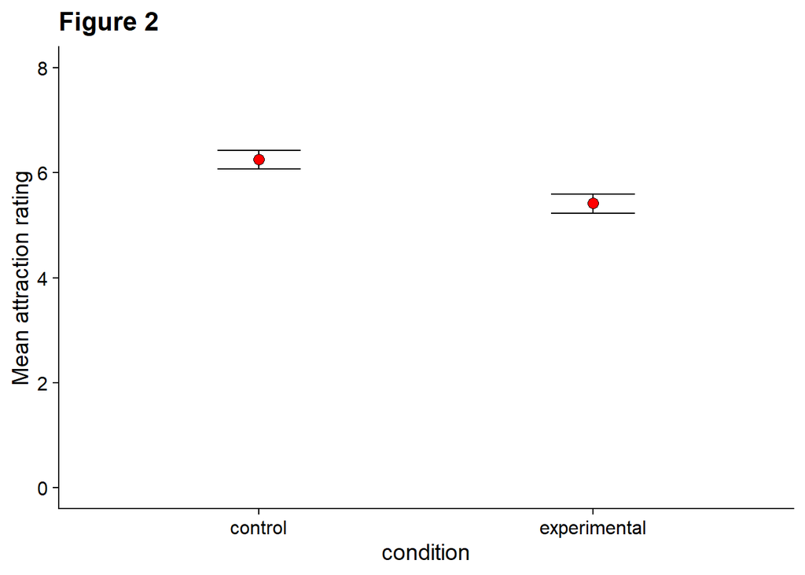

# Discussion

Overall our results showed that women rated men on a white background as significantly more attractive than when they were presented against a red background, meaning we reject our alternative hypothesis. This is the opposite finding as was initially proposed by Elliot et al, who instead found supporting evidence for the hypothesis, with women rating men significantly more attractive when presented against a red background compared to a white background (Elliot et al., 2010). However, our findings are in line with other research conducted by Peperkoorn et al, who investigated the red effect using a large sample of Dutch male participants. They also found that participants in the white condition rated women as more attractive than in the red condition (Peperkoorn et al., 2016). However, Peperkoorn et al conducted 2 further experiments into the effect of red on attraction ratings on large American samples and found no significant effect of colour on attraction in both experiments. However, this study looked at male’s attraction to females rather than the other way around as is in our study, limiting the ability to generalise these findings to our results. Nevertheless, Hesslinger et al also replicated Elliot et al’ s first experiment along with their own original experiment and found no significant effect of red on women’s perceived attraction of men, and instead found that the apparel was the factor that resulted in a significant effect on attractiveness ratings (Hesslinger et al., 2015). The lack of supporting replications for the influence of red on attraction ratings could be due to publication bias. Francis, 2013, used the Ioannidis and Trikanlinas test using the power values of the 7 experiments originally conducted by Elliot et al. Francis’ findings, suggested that it was highly likely that there was publication bias present in the research as the power values for attraction rating were low and fell below the threshold for publication bias, consequently questioning the robustness of the red effect found and suggested it was extremely unlikely for all of the experiments to produce significant results as was initially found (Francis, 2013). Elliot and Maier combated this accusation, claiming that Francis’ analysis of the results was bias and so they replicated the original study using a larger sample size but found no significant difference this time (Elliot & Maier, 2013). This finding can be interpreted as providing further evidence for the potential publication bias in the original study, or alternatively, the presence of null findings could in fact add validity to their original hypothesis, as Francis, 2013, in fact stated that the presence of a null effect may make the results more plausible as null effects are expected due to the low power value of the study.

One possible future area of research could focus on varying the initial attractiveness ratings of the men. Young conducted similar research focused on attractiveness ratings of females, and found that red only had an effect when the women were initially high in attractiveness (Young, 2015), if these results are replicated using a female sample assessing males it may explain our findings as we only used a picture of a moderately attractive male. Furthermore, research focusing on the difference between time exposure of the picture could be effective in distinguishing between the strength of red’s influence as the length of time that the participants are able to look at the photo may alter perceptions or allow red to become more or less influential. Similarly, other factors that are known to influence attraction ratings, such as facial expressions, attire and status should be explored in conjunction with red, in order to distinguish between the influence of red compared to other important factors. Based on our findings and those of Peperkoorn et al, I would also suggest further research into the effect of white on attraction ratings and its underlying connotations of purity and innocence (Peperkoorn et al., 2016) in order to analyse whether our findings have any replicable effects and meaning. This form of research could also be extended to look at other colours, and potentially even examine whether it is peoples initial colour preferences that may influence the impact the colour has on their perceived attractiveness of men.

In summary, our main findings did not support our hypothesis that red would increase attraction ratings of men or the original study conducted by Elliot et al, and instead we found that men were rated as significantly more attractive when presented on a white background compared to a red background. There was other research that supporting null findings for the effect of red (Elliot & Maier, 2013; Hesslinger et al., 2015; Peperkoorn et al., 2016), however very little support for our specific findings of white increasing attraction ratings. Overall, current research would suggest that there was little to no actual effect of red of increasing attraction to males, but further research and replications need to be conducted in order to conclude whether red has only a small effect on attraction or no effect at all.

# References

Elliot, A. J., & Maier, M. A. (2013). The red-attractiveness effect, applying the Ioannidis and Trikalinos (2007b) test, and the broader scientific context: A reply to Francis (2013). Journal of Experimental Psychology: General, 142(1), 297–300. http://dx.doi.org/10.1037/a0029592

Elliot, A. J., Niesta Kayser, D., Greitemeyer, T., Lichtenfeld, S., Gramzow, R. H., Maier, M. A., & Liu, H. (2010). Red, rank, and romance in women viewing men. Journal of Experimental Psychology: General, 139(3), 399–417. https://doi.org/10.1037/a0019689

Francis, G. (2013). Publication bias in “Red, rank, and romance in women viewing men,” by Elliot et al. (2010). Journal of Experimental Psychology: General, 142(1), 292–296. http://dx.doi.org/10.1037/a0027923

Hesslinger, V. M., Goldbach, L., & Carbon, C.-C. (2015). Men in red: A reexamination of the red-attractiveness effect. Psychonomic Bulletin & Review, 22(4), 1142–1148. https://doi.org/10.3758/s13423-015-0866-8

Peperkoorn, L. S., Roberts, S. C., & Pollet, T. V. (2016). Revisiting the Red Effect on Attractiveness and Sexual Receptivity: No Effect of the Color Red on Human Mate Preferences. Evolutionary Psychology, 14(4), 147470491667384. https://doi.org/10.1177/1474704916673841

Young, S. G. (2015). The effect of red on male perceptions of female attractiveness: Moderation by baseline attractiveness of female faces. European Journal of Social Psychology, 45(2), 146–151. https://doi.org/10.1002/ejsp.2098